# E-Commerce Data Analysis & Visualization Using Python

## Project Goal:

### This analysis aims to provide valuable insights into the sales performance, customer demographics, and operational efficiency of the most recent year for an E-Commerce company. By doing so, we can identify key revenue drivers, understand customer preferences, and uncover opportunities to enhance operational processes. These insights will help improve market strategy, drive sales growth, and increase overall efficiency.

### Data Source: https://www.kaggle.com/datasets/adarsh0806/influencer-merchandise-sales

## Data Collection & Cleaning:

### First, I imported essential libraries such as pandas, matplotlib, and seaborn for data manipulation and visualization. I then read the CSV file into a DataFrame and created a copy to maintain data integrity during the cleaning process.

### To ensure accuracy, I checked for null values and handled any missing data accordingly. Additionally, I searched for duplicate rows to avoid skewed analysis results.

### Recognizing the importance of correct data types, I reviewed and converted relevant columns to appropriate types. This included changing the Order Date to datetime format and converting categorical columns like Product Category, Buyer Gender, Order Location, and International Shipping to the category type.

### Using categorical data types reduces memory usage and allows for faster operations such as grouping and sorting. This optimization not only enhances processing speed but also makes the dataset more readable and intuitive by clearly indicating categorical data.

```python
# Import Necessary Libraries.
import pandas as pd
import matplotlib.pyplot as plt
import ipywidgets as widgets
import seaborn as sns
import numpy as np
from sklearn.preprocessing import StandardScaler
from sklearn.cluster import KMeans
```

```python
file_path = "./Downloads/archive (16)/merch_sales.csv"
```

```python
# Read the CSV file into a DataFrame
df = pd.read_csv(file_path)
```

```python
# Create a copy for cleaning
df_clean = df.copy()
```

```python
# Check for null values
null_values = df_clean.isnull().sum()
print("Null values in each column:\n", null_values)
```

```
Null values in each column:
 Order ID                  0
Order Date                0
Product ID                0
Product Category          0
Buyer Gender              0
Buyer Age                 0
Order Location            0
International Shipping    0
Sales Price               0
Shipping Charges          0
Sales per Unit            0
Quantity                  0
Total Sales               0
Rating                    0
Review                    0
dtype: int64
```

```python
# Check for duplicates
duplicate_rows = df_clean.duplicated().sum()
print("Number of duplicate rows:", duplicate_rows)
```

```
Number of duplicate rows: 0
```

```python
# Check data types of columns
data_types = df_clean.dtypes
print("Data types of each column:\n", data_types)
```

```
Data types of each column:
 Order ID                   int64
Order Date                object
Product ID                object
Product Category          object
Buyer Gender              object
Buyer Age                  int64
Order Location            object
International Shipping    object
Sales Price                int64
Shipping Charges           int64
Sales per Unit             int64
Quantity                   int64
Total Sales                int64
Rating                     int64
Review                    object
dtype: object
```

```python
# Correct data types
df_clean['Order Date'] = pd.to_datetime(df_clean['Order Date'])
df_clean['Product Category'] = df_clean['Product Category'].astype('category')
df_clean['Buyer Gender'] = df_clean['Buyer Gender'].astype('category')
df_clean['Order Location'] = df_clean['Order Location'].astype('category')
df_clean['International Shipping'] = df_clean['International Shipping'].astype('category')
```

```python
# Verify the changes
data_types = df_clean.dtypes
print("Data types of each column:\n", data_types)
```

```
Data types of each column:
 Order ID                           int64
Order Date                datetime64[ns]
Product ID                        object
Product Category                category
Buyer Gender                    category
Buyer Age                          int64
Order Location                  category
International Shipping          category
Sales Price                        int64
Shipping Charges                   int64
Sales per Unit                     int64
Quantity                           int64
Total Sales                        int64
Rating                             int64
Review                            object
dtype: object
```

```python
# Export the cleaned DataFrame to a CSV file
df_clean.to_csv('./Downloads/archive (16)/merch_sales.csv', index=False)
```

## Exploratory Data Analysis:

```python
# SUmmary statistics for all columns
print(df_clean.describe(include='all'))
```

```
             Order ID                     Order Date Product ID  \
count     7394.000000                           7394       7394
unique            NaN                            NaN         13
top               NaN                            NaN     BF1548
freq              NaN                            NaN       1497
mean    159735.134028  2024-05-02 16:09:05.307005696        NaN
min     120005.000000            2023-11-05 00:00:00        NaN
25%     139895.750000            2024-02-02 00:00:00        NaN
50%     159577.500000            2024-04-30 00:00:00        NaN
75%     179869.750000            2024-07-31 00:00:00        NaN
max     199994.000000            2024-11-04 00:00:00        NaN
std      23040.247194                            NaN        NaN

       Product Category Buyer Gender    Buyer Age Order Location  \
count              7394         7394  7394.000000           7394
unique                3            2          NaN             25
top            Clothing         Male          NaN     New Jersey
freq               3704         5188          NaN            434
mean                NaN          NaN    26.455504            NaN
min                 NaN          NaN    18.000000            NaN
25%                 NaN          NaN    22.000000            NaN
50%                 NaN          NaN    26.000000            NaN
75%                 NaN          NaN    31.000000            NaN
max                 NaN          NaN    35.000000            NaN
std                 NaN          NaN     5.208202            NaN

       International Shipping  Sales Price  Shipping Charges  Sales per Unit  \
count                    7394  7394.000000       7394.000000     7394.000000
unique                      2          NaN               NaN             NaN
top                        No          NaN               NaN             NaN
freq                     5139          NaN               NaN             NaN
mean                      NaN    55.165404         14.633487       69.798891
min                       NaN     9.000000          0.000000        9.000000
25%                       NaN    15.000000          0.000000       20.000000
50%                       NaN    65.000000          0.000000       65.000000
75%                       NaN    97.000000         40.000000      100.000000
max                       NaN   130.000000        100.000000      230.000000
std                       NaN    39.575614         24.815719       46.702326

           Quantity  Total Sales       Rating  \
```

[output cut: 9 more lines]

```
max        5.000000  1000.000000     5.000000
std        1.081398   118.067960     1.389731

                                                 Review
count                                              7394
unique                                               29
top     Lack of delivery delays is greatly appreciated.
freq                                                466
mean                                                NaN
min                                                 NaN
25%                                                 NaN
50%                                                 NaN
75%                                                 NaN
max                                                 NaN
std                                                 NaN
```

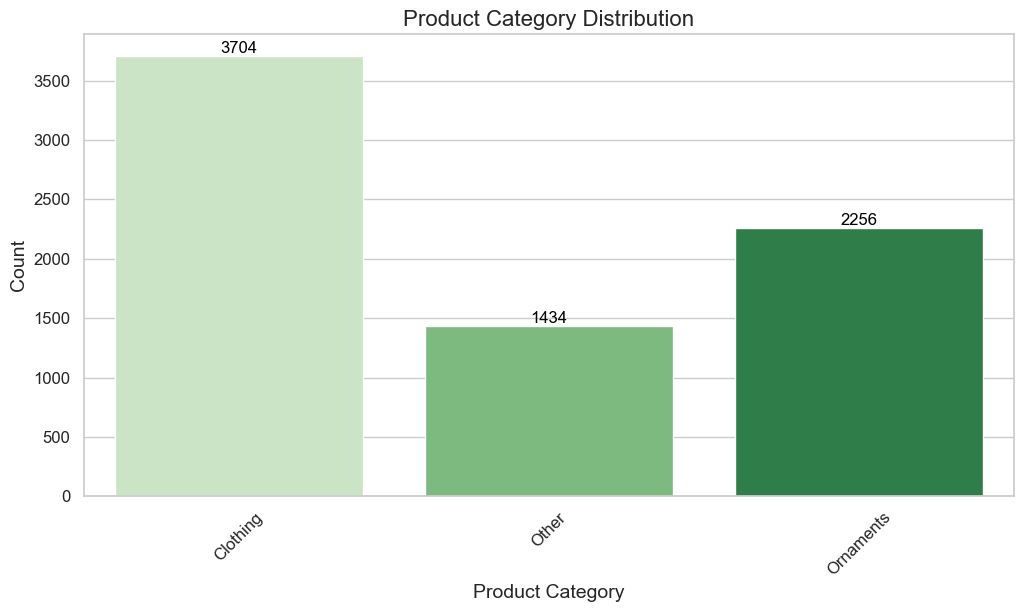

```python
# Set the theme for the plots
sns.set_theme(style="whitegrid", palette="Greens")

# Create a figure and axis for the plot
plt.figure(figsize=(12, 6))

# Create a count plot for Product Category
ax = sns.countplot(data=df, x='Product Category', hue='Product Category', dodge=False, palette='Greens', legend=False)

# Adding title and labels to the plot
plt.title('Product Category Distribution', fontsize=16)
plt.xlabel('Product Category', fontsize=14)
plt.ylabel('Count', fontsize=14)
plt.xticks(rotation=45, fontsize=12)
plt.yticks(fontsize=12)

# Annotate each bar with the count
for container in ax.containers:
    ax.bar_label(container, label_type='edge', fontsize=12, color='black')
plt.legend([], [], frameon=False)

# Display the plot
plt.show()
```

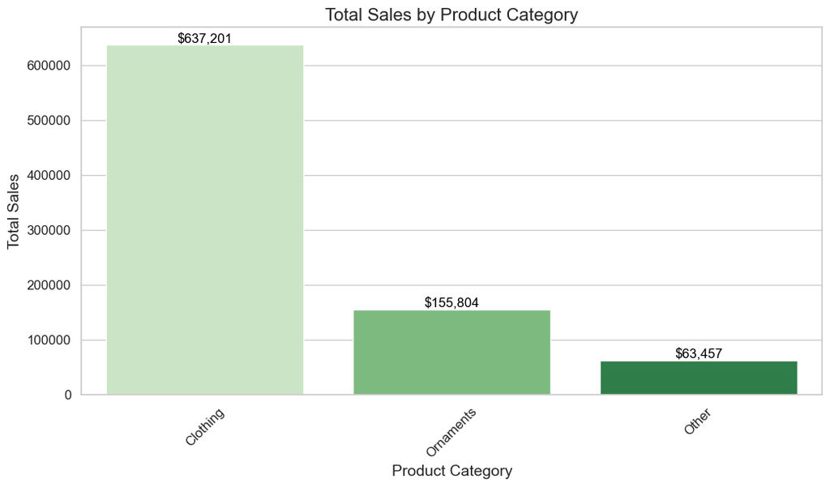

```python
# Set the theme for the plots
sns.set_theme(style="whitegrid", palette="Greens")

# Group by Product Category and sum up the Total Sales
category_sales = df_clean.groupby('Product Category', observed=True)['Total Sales'].sum().reset_index()

# Create a figure and axis for the plot
plt.figure(figsize=(12, 6))

# Create a bar plot for Total Sales by Product Category
ax = sns.barplot(data=category_sales, x='Product Category', y='Total Sales', hue='Product Category', dodge=False, palette='Greens', legend=False)

# Adding title and labels to the plot
plt.title('Total Sales by Product Category', fontsize=16)
plt.xlabel('Product Category', fontsize=14)
plt.ylabel('Total Sales', fontsize=14)
plt.xticks(rotation=45, fontsize=12)
plt.yticks(fontsize=12)

# Annotate each bar with the total sales, formatted with dollar signs and comma separators
for container in ax.containers:
    ax.bar_label(container, labels=[f'${v:,.0f}' for v in container.datavalues], fontsize=12, color='black')

# Display the plot
plt.show()
```

```python
# Group by Product ID and sum the Total Sales
product_sales = df_clean.groupby(['Product ID', 'Product Category'], observed=True)['Total Sales'].sum().reset_index()

# Sort by Total Sales and select the top 5 products
top_5_products = product_sales.sort_values(by='Total Sales', ascending=False).head(5)

# Display the top 5 products with their total sales and product category
print(top_5_products)
```

```
  Product ID Product Category  Total Sales
5     BF1548         Clothing       190640
0     BF1543         Clothing       144395
7     BF1550         Clothing       139691
6     BF1549         Clothing        88790
3     BF1546         Clothing        73685
```

```python
# Group by Product ID and Product Category, and sum the Total Sales
product_sales = df_clean.groupby(['Product ID', 'Product Category'], observed=True)['Total Sales'].sum().reset_index()

# Sort by Total Sales and select the top 5 products
top_5_products = product_sales.sort_values(by='Total Sales', ascending=False).head(5)

# Filter the original DataFrame to get additional details for the top 5 products
top_5_details = df_clean[df_clean['Product ID'].isin(top_5_products['Product ID'])]

# Group by Product ID and aggregate additional details
top_5_summary = top_5_details.groupby('Product ID').agg({
    'Product Category': 'first',
    'Sales Price': 'mean',
    'Quantity': 'sum',
    'Shipping Charges': 'sum',
    'Rating': 'mean',
    'Total Sales': 'sum'
}).reset_index()

# Display the summary
print(top_5_summary)
```

```
  Product ID Product Category  Sales Price  Quantity  Shipping Charges  \
0     BF1543         Clothing        100.0      1220             12485
1     BF1546         Clothing        118.0       555              5670
2     BF1548         Clothing         65.0      2421             20775
3     BF1549         Clothing        130.0       628              4625
4     BF1550         Clothing         97.0      1273             10235

     Rating  Total Sales
0  3.529820       144395
1  3.424581        73685
2  3.496994       190640
3  3.383598        88790
4  3.569333       139691
```

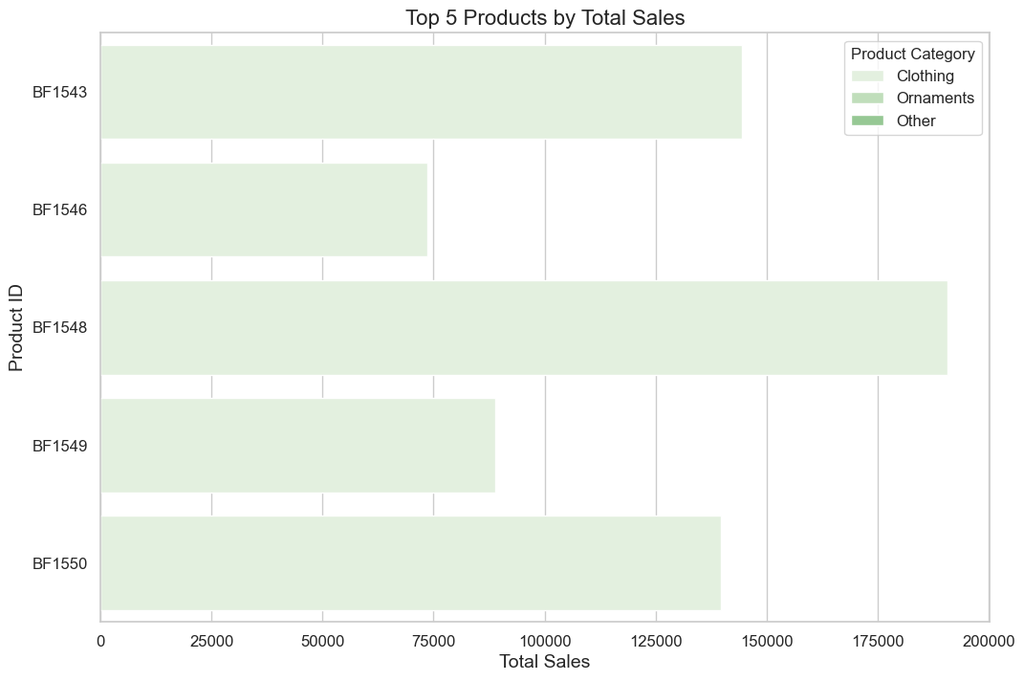

```python
# Set the theme for the plots
sns.set_theme(style="whitegrid", palette="Greens")

# Create a figure and axis for the plot
plt.figure(figsize=(12, 8))

# Create a bar plot for Total Sales by Product ID, with Product Category as hue
sns.barplot(x='Total Sales', y='Product ID', data=top_5_summary, hue='Product Category')

# Adding title and labels to the plot
plt.title('Top 5 Products by Total Sales', fontsize=16)
plt.xlabel('Total Sales', fontsize=14)
plt.ylabel('Product ID', fontsize=14)
plt.xticks(fontsize=12)
plt.yticks(fontsize=12)

# Adding a legend with the title 'Product Category'
plt.legend(title='Product Category', fontsize=12)

# Display the plot
plt.show()
```

```python
# Calculate the total sales for the entire dataset
total_sales = df_clean['Total Sales'].sum()

# Calculate the revenue contribution percentage for the top 5 products
top_5_summary['Revenue Contribution (%)'] = (top_5_summary['Total Sales'] / total_sales) * 100

# Display the summary with selected columns
print(top_5_summary[['Product ID', 'Product Category', 'Total Sales', 'Revenue Contribution (%)', 'Shipping Charges']])
```

```
  Product ID Product Category  Total Sales  Revenue Contribution (%)  \
0     BF1543         Clothing       144395                 16.859475
1     BF1546         Clothing        73685                  8.603417
2     BF1548         Clothing       190640                 22.259014
3     BF1549         Clothing        88790                 10.367068
4     BF1550         Clothing       139691                 16.310239

   Shipping Charges
0             12485
1              5670
2             20775
3              4625
4             10235
```

```python
# Group by Product ID and Product Category, and sum the Total Sales
product_sales = df_clean.groupby(['Product ID', 'Product Category'], observed=True)['Total Sales'].sum().reset_index()

# Sort by Total Sales and select the bottom 5 products
bottom_5_products = product_sales.sort_values(by='Total Sales', ascending=True).head(5)

# Filter the original DataFrame to get additional details for the bottom 5 products
bottom_5_details = df_clean[df_clean['Product ID'].isin(bottom_5_products['Product ID'])]

# Group by Product ID and aggregate additional details
bottom_5_summary = bottom_5_details.groupby('Product ID').agg({
    'Product Category': 'first',
    'Sales Price': 'mean',
    'Quantity': 'sum',
    'Shipping Charges': 'sum',
    'Rating': 'mean',
    'Total Sales': 'sum'
}).reset_index()

# Display the summary for the bottom 5 products
print(bottom_5_summary)
```

```
  Product ID Product Category  Sales Price  Quantity  Shipping Charges  \
0     BF1545            Other         10.0      1023              8650
1     BF1547        Ornaments         32.0       562              4665
2     BF1553        Ornaments         50.0       362              3275
3     BF1554        Ornaments         20.0       755              6535
4     BF1555            Other         23.0       227              1760

     Rating  Total Sales
0  3.604569        26630
1  3.453988        26554
2  3.452489        23505
3  3.511312        27070
4  3.571429         8666
```

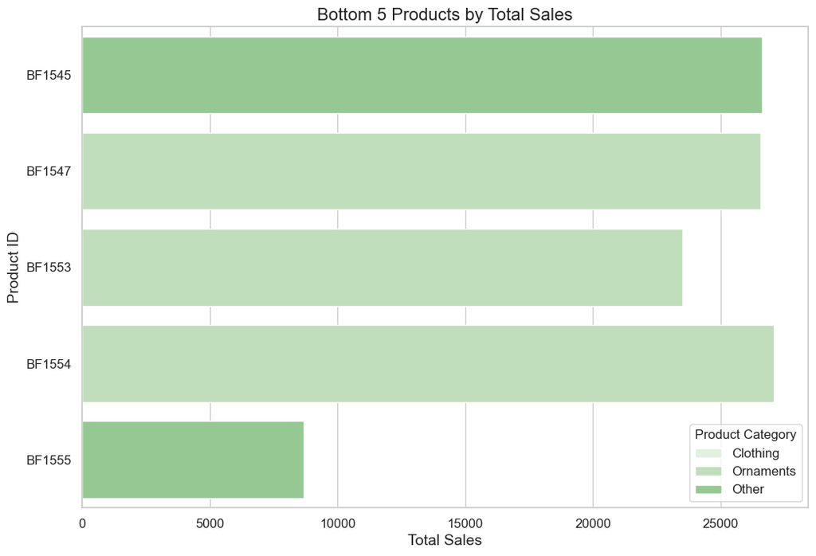

```python
# Set the theme for the plots
sns.set_theme(style="whitegrid", palette="Greens")

# Create a figure and axis for the plot
plt.figure(figsize=(12, 8))

# Create a bar plot for Total Sales by Product ID, with Product Category as hue
sns.barplot(x='Total Sales', y='Product ID', data=bottom_5_summary, hue='Product Category')

# Adding title and labels to the plot
plt.title('Bottom 5 Products by Total Sales', fontsize=16)
plt.xlabel('Total Sales', fontsize=14)
plt.ylabel('Product ID', fontsize=14)
plt.xticks(fontsize=12)
plt.yticks(fontsize=12)

# Adding a legend with the title 'Product Category'
plt.legend(title='Product Category', fontsize=12)

# Display the plot
plt.show()
```

```python
# Calculate the total sales for the entire dataset
total_sales = df_clean['Total Sales'].sum()

# Calculate the revenue contribution percentage for the bottom 5 products
bottom_5_summary['Revenue Contribution (%)'] = (bottom_5_summary['Total Sales'] / total_sales) * 100

# Display the summary with selected columns
print(bottom_5_summary[['Product ID', 'Product Category', 'Total Sales', 'Revenue Contribution (%)', 'Shipping Charges']])
```

```
  Product ID Product Category  Total Sales  Revenue Contribution (%)  \
0     BF1545            Other        26630                  3.109303
1     BF1547        Ornaments        26554                  3.100429
2     BF1553        Ornaments        23505                  2.744430
3     BF1554        Ornaments        27070                  3.160677
4     BF1555            Other         8666                  1.011837

   Shipping Charges
0              8650
1              4665
2              3275
3              6535
4              1760
```

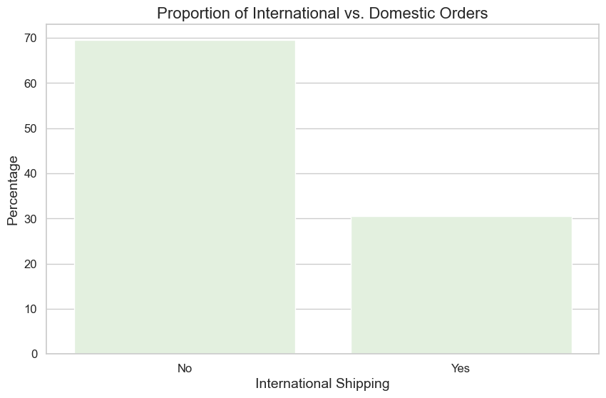

```python
# Calculate the proportion of International vs. Domestic orders
international_shipping_counts = df_clean['International Shipping'].value_counts(normalize=True) * 100

# Set the theme for the plots
sns.set_theme(style="whitegrid", palette="Greens")

# Create a figure and axis for the plot
plt.figure(figsize=(10, 6))

# Create a bar plot for International Shipping
sns.barplot(x=international_shipping_counts.index, y=international_shipping_counts.values)

# Adding title and labels to the plot
plt.title('Proportion of International vs. Domestic Orders', fontsize=16)
plt.ylabel('Percentage', fontsize=14)
plt.xlabel('International Shipping', fontsize=14)
plt.xticks(fontsize=12)
plt.yticks(fontsize=12)

# Display the plot
plt.show()
```

```python
# Calculate Total Sales and Shipping Charges by International Shipping
shipping_summary = df_clean.groupby('International Shipping', observed=True).agg({
    'Total Sales': 'sum',
    'Shipping Charges': 'sum'
}).reset_index()

# Print the summary table
print(shipping_summary)

# Transform the data for a clustered bar plot
shipping_summary_melted = shipping_summary.melt(id_vars='International Shipping', value_vars=['Total Sales', 'Shipping Charges'],
                                                var_name='Metric', value_name='Value')
```

```
  International Shipping  Total Sales  Shipping Charges
0                     No       469606                 0
1                    Yes       386856            108200
```

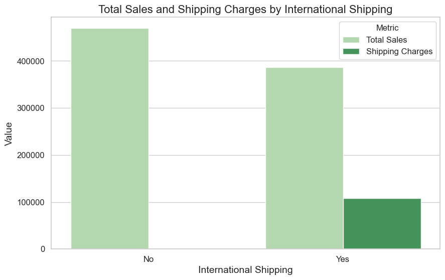

```python
# Set the theme for the plots
sns.set_theme(style="whitegrid")

# Create a figure and axis for the clustered bar plot
plt.figure(figsize=(10, 6))

# Create a bar plot for Total Sales and Shipping Charges by International Shipping
sns.barplot(x='International Shipping', y='Value', hue='Metric', data=shipping_summary_melted, palette='Greens')

# Adding title and labels to the plot
plt.title('Total Sales and Shipping Charges by International Shipping', fontsize=16)
plt.xlabel('International Shipping', fontsize=14)
plt.ylabel('Value', fontsize=14)
plt.xticks(fontsize=12)
plt.yticks(fontsize=12)

# Adding a legend with the title 'Metric'
plt.legend(title='Metric', loc='upper right', fontsize=12)

# Display the plot
plt.show()
```

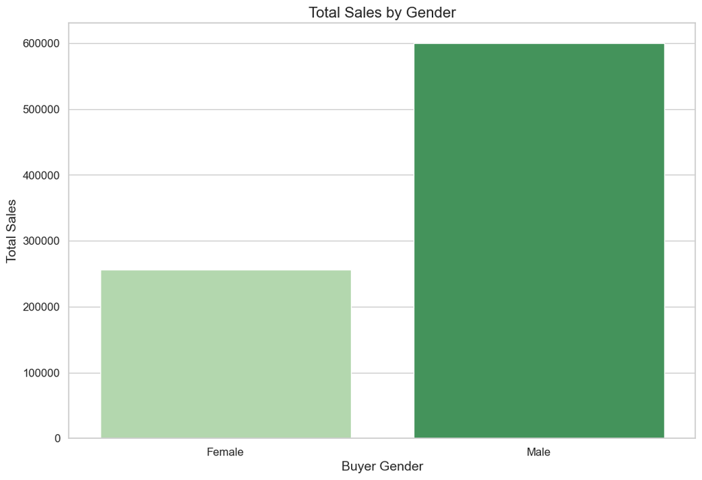

```python
# Group by Buyer Gender and sum up the Total Sales, with observed=True
gender_sales = df_clean.groupby('Buyer Gender', observed=True)['Total Sales'].sum().reset_index()

# Set the theme for the plots
sns.set_theme(style="whitegrid", palette="Greens")

# Create a figure and axis for the plot
plt.figure(figsize=(12, 8))

# Create a bar plot for Total Sales by Buyer Gender, with hue set to Buyer Gender and legend=False
sns.barplot(x='Buyer Gender', y='Total Sales', data=gender_sales, hue='Buyer Gender', dodge=False, palette='Greens', legend=False)

# Adding title and labels to the plot
plt.title('Total Sales by Gender', fontsize=16)
plt.xlabel('Buyer Gender', fontsize=14)
plt.ylabel('Total Sales', fontsize=14)
plt.xticks(fontsize=12)
plt.yticks(fontsize=12)

# Display the plot
plt.show()
```

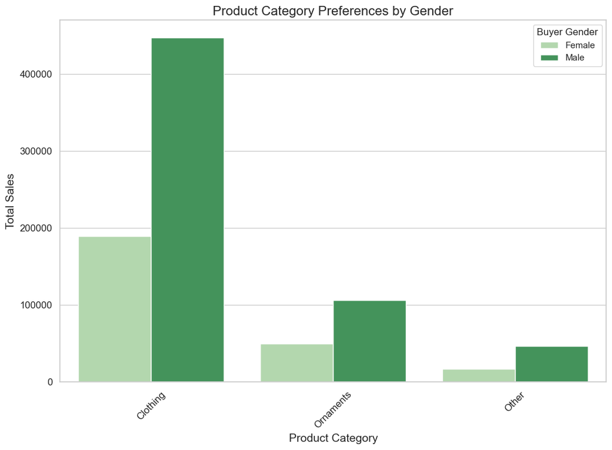

```python
# Group by Buyer Gender and Product Category and sum up the Total Sales, with observed=True
gender_category_sales = df_clean.groupby(['Buyer Gender', 'Product Category'], observed=True)['Total Sales'].sum().reset_index()

# Set the theme for the plots
sns.set_theme(style="whitegrid")

# Create a figure and axis for the plot
plt.figure(figsize=(12, 8))

# Create a bar plot for Total Sales by Product Category with Buyer Gender as hue
sns.barplot(x='Product Category', y='Total Sales', hue='Buyer Gender', data=gender_category_sales, palette='Greens')

# Adding title and labels to the plot
plt.title('Product Category Preferences by Gender', fontsize=16)
plt.xlabel('Product Category', fontsize=14)
plt.ylabel('Total Sales', fontsize=14)
plt.xticks(rotation=45, fontsize=12)
plt.yticks(fontsize=12)

# Display the plot
plt.show()
```

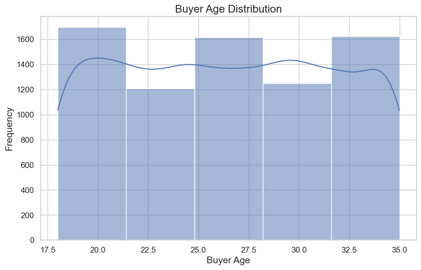

```python
# Create a figure and axis for the plot
plt.figure(figsize=(10, 6))

# Create a histogram for Buyer Age with Kernel Density Estimate (KDE)
sns.histplot(df_clean['Buyer Age'], bins=5, kde=True)

# Adding title to the plot
plt.title('Buyer Age Distribution', fontsize=16)
plt.xlabel('Buyer Age', fontsize=14)
plt.ylabel('Frequency', fontsize=14)
plt.xticks(fontsize=12)
plt.yticks(fontsize=12)

# Display the plot
plt.show()
```

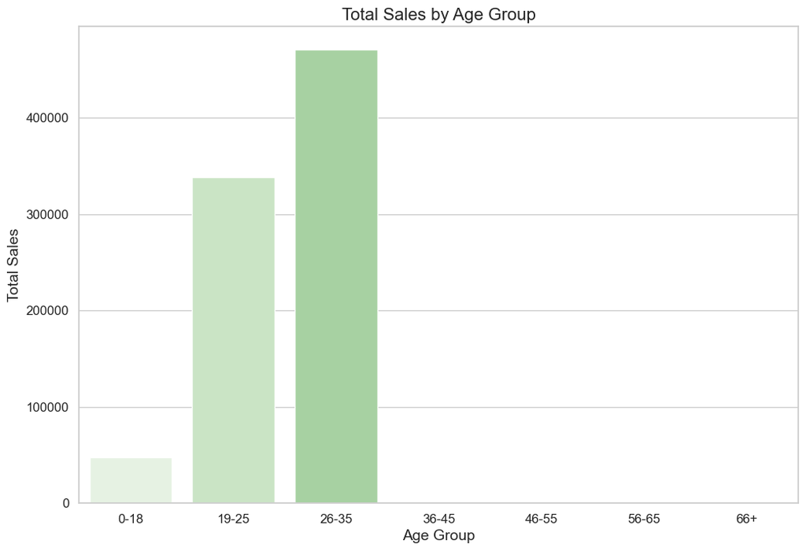

```python
# Create age groups by segmenting Buyer Age into bins and labeling them
df_clean['Age Group'] = pd.cut(df_clean['Buyer Age'], bins=[0, 18, 25, 35, 45, 55, 65, 100],
                               labels=['0-18', '19-25', '26-35', '36-45', '46-55', '56-65', '66+'])

# Group by Age Group and sum the Total Sales, with observed=True
age_group_sales = df_clean.groupby('Age Group', observed=True)['Total Sales'].sum().reset_index()

# Set the theme for the plots
sns.set_theme(style="whitegrid", palette="Greens")

# Create a figure and axis for the plot
plt.figure(figsize=(12, 8))

# Create a bar plot for Total Sales by Age Group, with hue set to Age Group and legend=False
sns.barplot(x='Age Group', y='Total Sales', data=age_group_sales, hue='Age Group', dodge=False, palette='Greens', legend=False)

# Adding title and labels to the plot
plt.title('Total Sales by Age Group', fontsize=16)
plt.xlabel('Age Group', fontsize=14)
plt.ylabel('Total Sales', fontsize=14)
plt.xticks(fontsize=12)
plt.yticks(fontsize=12)

# Display the plot
plt.show()
```

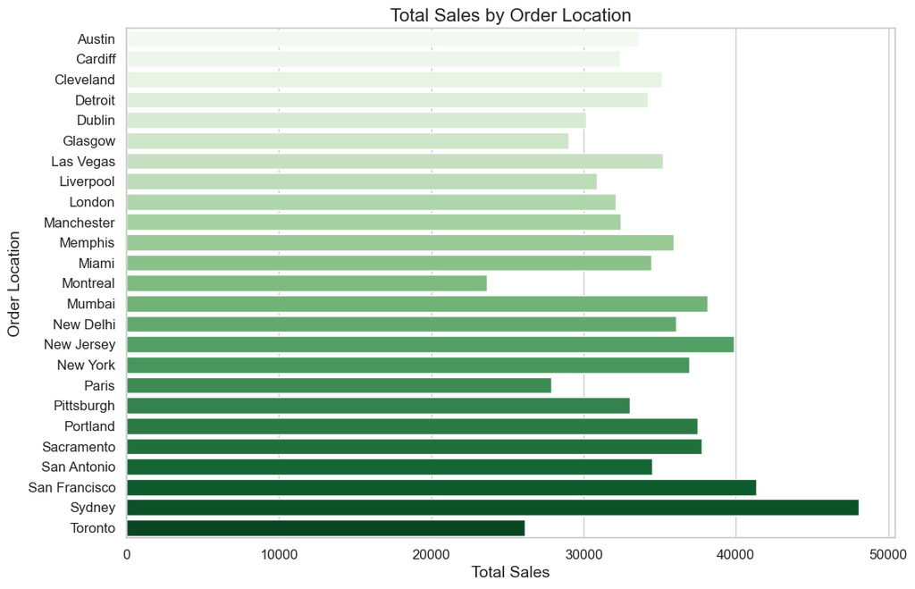

```python
# Group by Order Location and sum the Total Sales, with observed=True
location_sales = df_clean.groupby('Order Location', observed=True)['Total Sales'].sum().reset_index()

# Set the theme for the plots
sns.set_theme(style="whitegrid", palette="Greens")

# Create a figure and axis for the plot
plt.figure(figsize=(12, 8))

# Create a bar plot for Total Sales by Order Location, with hue set to Order Location and legend=False
sns.barplot(x='Total Sales', y='Order Location', data=location_sales, hue='Order Location', dodge=False, palette='Greens', legend=False)

# Adding title and labels to the plot
plt.title('Total Sales by Order Location', fontsize=16)
plt.xlabel('Total Sales', fontsize=14)
plt.ylabel('Order Location', fontsize=14)
plt.xticks(fontsize=12)
plt.yticks(fontsize=12)

# Display the plot
plt.show()
```

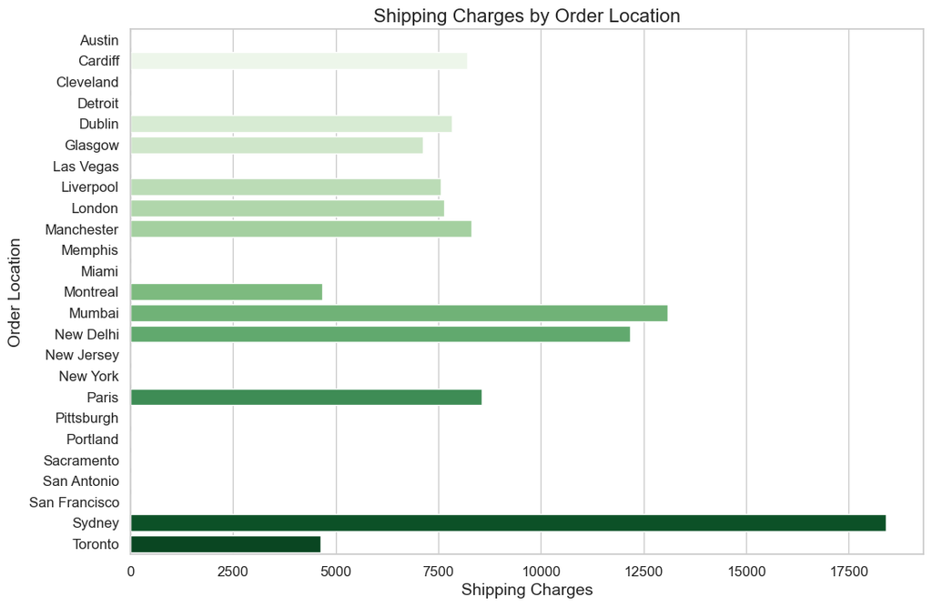

```python
# Group by Order Location and sum the Shipping Charges, with observed=True
location_shipping_charges = df_clean.groupby('Order Location', observed=True)['Shipping Charges'].sum().reset_index()

# Set the theme for the plots
sns.set_theme(style="whitegrid", palette="Greens")

# Create a figure and axis for the plot
plt.figure(figsize=(12, 8))

# Create a bar plot for Shipping Charges by Order Location, with hue set to Order Location and legend=False
sns.barplot(x='Shipping Charges', y='Order Location', data=location_shipping_charges, hue='Order Location', dodge=False, palette='Greens', legend=False)

# Adding title and labels to the plot
plt.title('Shipping Charges by Order Location', fontsize=16)
plt.xlabel('Shipping Charges', fontsize=14)
plt.ylabel('Order Location', fontsize=14)
plt.xticks(fontsize=12)
plt.yticks(fontsize=12)

# Display the plot
plt.show()
```

```python
# Create a new column for the month by extracting the month from the Order Date
df_clean['Month'] = df_clean['Order Date'].dt.to_period('M').astype(str)
```

```python
# Group by Month and sum up the Total Sales
monthly_sales = df_clean.groupby('Month')['Total Sales'].sum().reset_index()
```

```python
# Convert the Month column to datetime format
monthly_sales['Month'] = pd.to_datetime(monthly_sales['Month'])

# Sort the DataFrame by the Month column
monthly_sales.sort_values('Month', inplace=True)
```

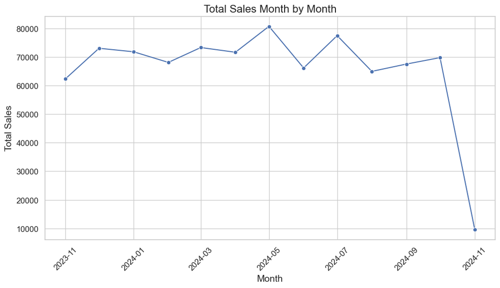

```python
# Set the theme for the plots
sns.set_theme(style="whitegrid")

# Create a figure and axis for the plot
plt.figure(figsize=(12, 6))

# Create a line plot for Total Sales by Month
sns.lineplot(x='Month', y='Total Sales', data=monthly_sales, marker='o')

# Adding title and labels to the plot
plt.title('Total Sales Month by Month', fontsize=16)
plt.xlabel('Month', fontsize=14)
plt.ylabel('Total Sales', fontsize=14)
plt.xticks(rotation=45, fontsize=12)
plt.yticks(fontsize=12)

# Display the plot
plt.show()
```

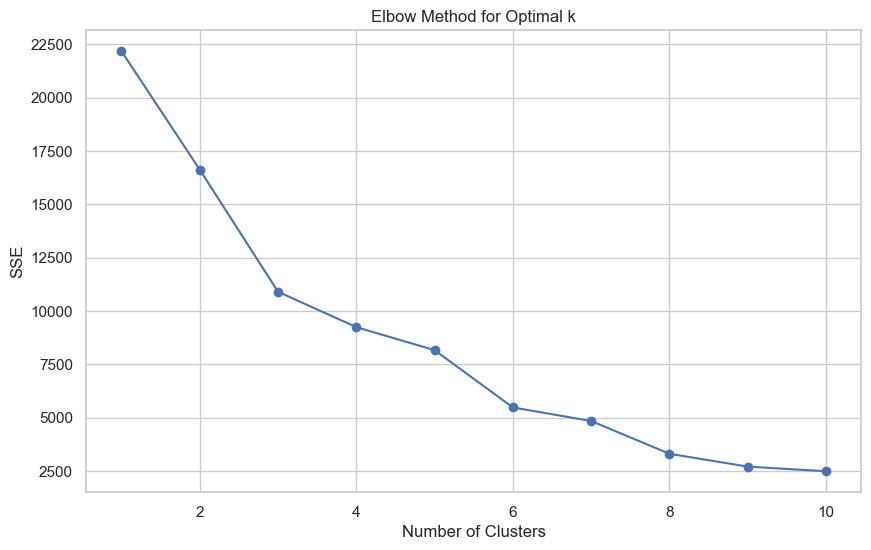

```
   Cluster  Buyer Age Buyer Gender Product Category  Total Sales
0        0  26.297824       Female         Clothing       256133
1        1  31.112515         Male         Clothing       284219
2        2  22.143503         Male         Clothing       316110
```

```python
# Prepare the data
features = df_clean[['Buyer Age', 'Buyer Gender', 'Product Category']].copy()
features['Buyer Gender'] = features['Buyer Gender'].cat.codes  # Convert categories to numeric codes
features['Product Category'] = features['Product Category'].cat.codes  # Convert categories to numeric codes

# Standardize the features
scaler = StandardScaler()
features_scaled = scaler.fit_transform(features)

# Determine the optimal number of clusters using the Elbow Method
sse = []
for k in range(1, 11):
    kmeans = KMeans(n_clusters=k, random_state=42)
    kmeans.fit(features_scaled)
    sse.append(kmeans.inertia_)

plt.figure(figsize=(10, 6))
plt.plot(range(1, 11), sse, marker='o')
plt.title('Elbow Method for Optimal k')
plt.xlabel('Number of Clusters')
plt.ylabel('SSE')
plt.show()

# Running K-Means with the chosen number of clusters (e.g., k=3)
kmeans = KMeans(n_clusters=3, random_state=42)
clusters = kmeans.fit_predict(features_scaled)

# Add the cluster labels to the original DataFrame
df_clean['Cluster'] = kmeans.labels_

# Analyze the clusters
cluster_summary = df_clean.groupby('Cluster').agg({
    'Buyer Age': 'mean',
    'Buyer Gender': lambda x: x.value_counts().idxmax(),  # Most common gender in each cluster
    'Product Category': lambda x: x.value_counts().idxmax(),  # Most common category in each cluster
    'Total Sales': 'sum'
}).reset_index()

print(cluster_summary)
```

```python
from sklearn.preprocessing import StandardScaler

# Prepare the data
features = df_clean[['Buyer Age', 'Buyer Gender', 'Product Category', 'Product ID', 'International Shipping']].copy()
features['Buyer Gender'] = features['Buyer Gender'].cat.codes  # Convert categories to numeric codes
features['Product Category'] = features['Product Category'].cat.codes  # Convert categories to numeric codes
features['Product ID'] = features['Product ID'].astype('category').cat.codes  # Convert Product ID to numeric codes
features['International Shipping'] = features['International Shipping'].cat.codes  # Convert International Shipping to numeric codes

# Standardize the features
scaler = StandardScaler()
features_scaled = scaler.fit_transform(features)

# Verify the standardized features
print(features_scaled[:5])
```

```
[[ 0.6806063   0.65208284 -0.89417858 -1.56487686 -0.66242081]
 [ 1.06464194  0.65208284 -0.89417858 -1.56487686 -0.66242081]
 [-0.08746497 -1.53354749  1.68644454 -1.26338383  1.50961442]
 [ 0.29657067  0.65208284  1.68644454 -1.26338383 -0.66242081]
 [-1.43158971 -1.53354749  1.68644454 -0.9618908  -0.66242081]]
```

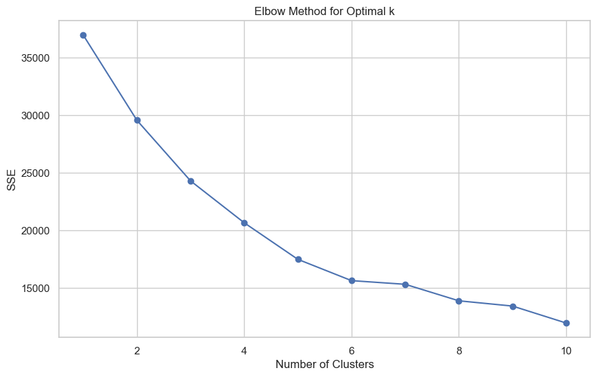

```python
# Determine the optimal number of clusters using the Elbow Method
sse = []
for k in range(1, 11):
    kmeans = KMeans(n_clusters=k, random_state=42)
    kmeans.fit(features_scaled)
    sse.append(kmeans.inertia_)

plt.figure(figsize=(10, 6))
plt.plot(range(1, 11), sse, marker='o')
plt.title('Elbow Method for Optimal k')
plt.xlabel('Number of Clusters')
plt.ylabel('SSE')
plt.show()
```

```python
# Running K-Means with the chosen number of clusters (e.g., k=3)
kmeans = KMeans(n_clusters=5, random_state=42)
clusters = kmeans.fit_predict(features_scaled)

# Add the cluster labels to the original DataFrame
df_clean['Cluster'] = kmeans.labels_
```

```python
# Analyze the clusters
cluster_summary = df_clean.groupby('Cluster').agg({
    'Buyer Age': 'mean',
    'Buyer Gender': lambda x: x.value_counts().idxmax(),  # Most common gender in each cluster
    'Product Category': lambda x: x.value_counts().idxmax(),  # Most common category in each cluster
    'Product ID': lambda x: x.value_counts().idxmax(),  # Most common product in each cluster
    'International Shipping': lambda x: x.value_counts().idxmax(),  # Most common value for International Shipping in each cluster
    'Total Sales': 'sum'
}).reset_index()

print(cluster_summary)
```

```
   Cluster  Buyer Age Buyer Gender Product Category Product ID  \
0        0  26.276033       Female         Clothing     BF1548
1        1  26.642272         Male         Clothing     BF1548
2        2  26.488086         Male            Other     BF1544
3        3  26.354167         Male        Ornaments     BF1551
4        4  26.475552         Male         Clothing     BF1548

  International Shipping  Total Sales
0                     No       240761
1                     No       274527
2                     No        54791
3                     No        45165
4                    Yes       241218
```

```python
# Group by Order Location to sum up Total Sales and Shipping Charges, with observed=True
location_summary = df_clean.groupby('Order Location', observed=True).agg({
    'Total Sales': 'sum',
    'Shipping Charges': 'sum'
}).reset_index()

# Replace zero shipping charges with NaN to avoid division by zero
location_summary['Shipping Charges'] = location_summary['Shipping Charges'].replace(0, np.nan)

# Calculate the ratio of Total Sales to Shipping Charges
location_summary['Sales to Shipping Ratio'] = location_summary['Total Sales'] / location_summary['Shipping Charges']

# Fill NaN values with 0 for the ratio column
location_summary['Sales to Shipping Ratio'] = location_summary['Sales to Shipping Ratio'].fillna(0)

# Display the summary table
print(location_summary[['Order Location', 'Total Sales', 'Shipping Charges', 'Sales to Shipping Ratio']])
```

```
   Order Location  Total Sales  Shipping Charges  Sales to Shipping Ratio
0          Austin        33655               NaN                 0.000000
1         Cardiff        32397            8200.0                 3.950854
2       Cleveland        35153               NaN                 0.000000
3         Detroit        34240               NaN                 0.000000
4          Dublin        30172            7840.0                 3.848469
5         Glasgow        29000            7120.0                 4.073034
6       Las Vegas        35234               NaN                 0.000000
7       Liverpool        30875            7560.0                 4.083995
8          London        32104            7640.0                 4.202094
9      Manchester        32426            8320.0                 3.897356
10        Memphis        35900               NaN                 0.000000
11          Miami        34460               NaN                 0.000000
12       Montreal        23644            4675.0                 5.057540
13         Mumbai        38115           13090.0                 2.911765
14      New Delhi        36054           12180.0                 2.960099
15     New Jersey        39889               NaN                 0.000000
16       New York        36959               NaN                 0.000000
17          Paris        27857            8550.0                 3.258129
18     Pittsburgh        33013               NaN                 0.000000
19       Portland        37506               NaN                 0.000000
20     Sacramento        37756               NaN                 0.000000
21    San Antonio        34520               NaN                 0.000000
22  San Francisco        41321               NaN                 0.000000
23         Sydney        48049           18400.0                 2.611359
24        Toronto        26163            4625.0                 5.656865
```

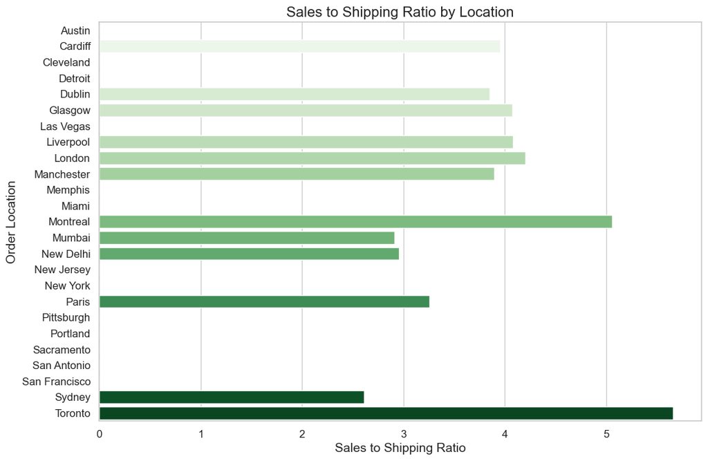

```python
# Set the theme for the plots
sns.set_theme(style="whitegrid")

# Create a figure and axis for the plot
plt.figure(figsize=(12, 8))

# Create a bar plot for the Sales to Shipping Ratio by Order Location, with hue set to Order Location and legend=False
sns.barplot(x='Sales to Shipping Ratio', y='Order Location', data=location_summary, hue='Order Location', dodge=False, palette='Greens', legend=False)

# Adding title and labels to the plot
plt.title('Sales to Shipping Ratio by Location', fontsize=16)
plt.xlabel('Sales to Shipping Ratio', fontsize=14)
plt.ylabel('Order Location', fontsize=14)
plt.xticks(fontsize=12)
plt.yticks(fontsize=12)

# Display the plot
plt.show()
```

```python
# Group by Order Location to sum up Total Sales and Shipping Charges
location_summary = df_clean.groupby('Order Location', observed=True).agg({
    'Total Sales': 'sum',
    'Shipping Charges': 'sum'
}).reset_index()

# Replace zero shipping charges with NaN to avoid division by zero
location_summary['Shipping Charges'] = location_summary['Shipping Charges'].replace(0, np.nan)

# Calculate the ratio of Total Sales to Shipping Charges
location_summary['Sales to Shipping Ratio'] = location_summary['Total Sales'] / location_summary['Shipping Charges']

# Filter the data to include only records with a Sales to Shipping Ratio greater than 0
filtered_location_summary = location_summary[location_summary['Sales to Shipping Ratio'] > 0].reset_index(drop=True)

# Sort the DataFrame by Sales to Shipping Ratio from highest to lowest
sorted_location_summary = filtered_location_summary.sort_values(by='Sales to Shipping Ratio', ascending=False)

# Display the sorted summary table
print(sorted_location_summary[['Order Location', 'Total Sales', 'Shipping Charges', 'Sales to Shipping Ratio']])
```

```
   Order Location  Total Sales  Shipping Charges  Sales to Shipping Ratio
11        Toronto        26163            4625.0                 5.656865
6        Montreal        23644            4675.0                 5.057540
4          London        32104            7640.0                 4.202094
3       Liverpool        30875            7560.0                 4.083995
2         Glasgow        29000            7120.0                 4.073034
0         Cardiff        32397            8200.0                 3.950854
5      Manchester        32426            8320.0                 3.897356
1          Dublin        30172            7840.0                 3.848469
9           Paris        27857            8550.0                 3.258129
8       New Delhi        36054           12180.0                 2.960099
7          Mumbai        38115           13090.0                 2.911765
10         Sydney        48049           18400.0                 2.611359
```

```python
# Count the frequency of each review
review_counts = df_clean['Review'].value_counts().reset_index()

# Rename the columns for clarity
review_counts.columns = ['Review', 'Count']

# Calculate the percentage of total reviews
review_counts['Percentage of Total Reviews'] = (review_counts['Count'] / df_clean['Review'].count()) * 100

# Select the top 10 most frequent reviews
top_10_reviews = review_counts.head(30)

# Display the top 10 reviews, their counts, and percentage of total reviews
print(top_10_reviews)
```

```
                                               Review  Count  \
0     Lack of delivery delays is greatly appreciated.    466
1    The delivery team handled the product with care.    448
2             Discount deals was greatly appreciated.    434
3   The product was affordable here compared to ot...    421
4   Great design is one of the major positives of ...    406
5                  The product was delivered quickly.    402
6                  The product had excellent quality.    391
7                   The Product exhibits good design.    382
8                           Premium quality as usual.    365
9   Exquisite craftsmanship here is absolutely app...    359
10          Incredible detailing was clearly evident.    356
11  The handling was questionable but incurred onl...    277
12  Had slight delays but the product was in good ...    270
13                                    Waste of Money.    190
```

[output cut: 46 more lines]

```python
# Calculate the average sales price for each product category
average_sales_prices = df_clean.groupby('Product Category', observed=True)['Sales Price'].mean().reset_index()

# Rename the column for clarity
average_sales_prices.rename(columns={'Sales Price': 'Average Price'}, inplace=True)

# Output the average sales prices
print(average_sales_prices)
```

```
  Product Category  Average Price
0         Clothing      90.048326
1        Ornaments      26.160018
2            Other      10.695258
```

```python
# Group by Product Category and calculate total revenue and number of unique orders
grouped_df = df_clean.groupby('Product Category', observed=True).agg(
    Total_Revenue=('Total Sales', 'sum'),
    Total_Orders=('Order ID', 'nunique')
).reset_index()

# Calculate average spending per order
grouped_df['Average Spending per Order'] = grouped_df['Total_Revenue'] / grouped_df['Total_Orders']

# Output the average spending per order
print(grouped_df[['Product Category', 'Average Spending per Order']])
```

```
  Product Category  Average Spending per Order
0         Clothing                  172.030508
1        Ornaments                   69.062057
2            Other                   44.251743
```

```python
def create_plots():
    fig, axs = plt.subplots(5, 2, figsize=(20, 36))  # 5x2 grid of subplots

    # Plot 1: Product Category Distribution
    sns.set_theme(style="whitegrid", palette="Greens")
    sns.countplot(data=df, x='Product Category', hue='Product Category', dodge=False, palette='Greens', ax=axs[0, 0])
    axs[0, 0].set_title('Product Category Distribution', fontsize=16)

    # Plot 2: Total Sales by Product Category
    category_sales = df_clean.groupby('Product Category', observed=True)['Total Sales'].sum().reset_index()
    sns.barplot(data=category_sales, x='Product Category', y='Total Sales', hue='Product Category', dodge=False, palette='Greens', ax=axs[0, 1])
    axs[0, 1].set_title('Total Sales by Product Category', fontsize=16)

    # Plot 3: Top 5 Products by Total Sales
    sns.barplot(x='Total Sales', y='Product ID', data=top_5_summary, hue='Product Category', ax=axs[1, 0])
    axs[1, 0].set_title('Top 5 Products by Total Sales', fontsize=16)

    # Plot 4: Bottom 5 Products by Total Sales
    sns.barplot(x='Total Sales', y='Product ID', data=bottom_5_summary, hue='Product Category', ax=axs[1, 1])
    axs[1, 1].set_title('Bottom 5 Products by Total Sales', fontsize=16)

    # Plot 5: International vs. Domestic Orders
    sns.set_theme(style="whitegrid", palette="Greens")
    international_shipping_counts = df_clean['International Shipping'].value_counts(normalize=True) * 100
    sns.barplot(x=international_shipping_counts.index, y=international_shipping_counts.values, ax=axs[2, 0])
    axs[2, 0].set_title('Proportion of International vs. Domestic Orders', fontsize=16)

    # Plot 6: Total Sales and Shipping Charges by International Shipping
    sns.barplot(x='International Shipping', y='Value', hue='Metric', data=shipping_summary_melted, palette='Greens', ax=axs[2, 1])
    axs[2, 1].set_title('Total Sales and Shipping Charges by International Shipping', fontsize=16)

    # Plot 7: Total Sales by Gender
    gender_sales = df_clean.groupby('Buyer Gender', observed=True)['Total Sales'].sum().reset_index()
    sns.barplot(x='Buyer Gender', y='Total Sales', data=gender_sales, hue='Buyer Gender', dodge=False, palette='Greens', ax=axs[3, 0])
    axs[3, 0].set_title('Total Sales by Gender', fontsize=16)

    # Plot 8: Product Category Preferences by Gender
    gender_category_sales = df_clean.groupby(['Buyer Gender', 'Product Category'], observed=True)['Total Sales'].sum().reset_index()
    sns.barplot(x='Product Category', y='Total Sales', hue='Buyer Gender', data=gender_category_sales, palette='Greens', ax=axs[3, 1])
    axs[3, 1].set_title('Product Category Preferences by Gender', fontsize=16)

    # Plot 9: Total Sales by Age Group
    df_clean['Age Group'] = pd.cut(df_clean['Buyer Age'], bins=[0, 18, 25, 35, 45, 55, 65, 100], labels=['0-18', '19-25', '26-35', '36-45', '46-55', '56-65', '66+'])
    age_group_sales = df_clean.groupby('Age Group', observed=True)['Total Sales'].sum().reset_index()
    sns.barplot(x='Age Group', y='Total Sales', data=age_group_sales, hue='Age Group', dodge=False, palette='Greens', ax=axs[4, 0])
    axs[4, 0].set_title('Total Sales by Age Group', fontsize=16)

    # Plot 10: Total Sales by Order Location
    location_sales = df_clean.groupby('Order Location', observed=True)['Total Sales'].sum().reset_index()
    sns.barplot(x='Total Sales', y='Order Location', data=location_sales, hue='Order Location', dodge=False, palette='Greens', ax=axs[4, 1])
    axs[4, 1].set_title('Total Sales by Order Location', fontsize=16)

    plt.tight_layout()
    plt.show()

output = widgets.Output()

with output:
    create_plots()

scrollable = widgets.VBox([output], layout=widgets.Layout(height='1000px', overflow='scroll'))
scrollable
```

[output not shown]

```
VBox(children=(Output(),), layout=Layout(height='1000px', overflow='scroll'))
```

## Key Insights:

### 1. Sales Overview:

[output not shown]

### 2. Product Overview:

```
    * Top 5 Products all belong to Clothing category.
    (The most notable being product BF1548 which contributes $190,640 equating to 22.25% revenue contribution)
    * Bottom 5 Products belong to the categories Ornaments and Other.
(The most notable being product BF1555 which contributes $8,666 equating to 1.01% revenue contribution)
```

### 3. Order Distribution:

```
    * Domestic Orders: 69% of total orders, contributing $469,606 with no shipping charges.
* International Orders: 31% of total orders, contributing $386,856 but incurring $108,200 in shipping charges.
```

### 4. Demorgraphic & Cluster Analysis:

```
    * Male buyers dominate with $600,000 in sales.
* The 26-35 age group is the prime spender, contributing nearly $480,000.
    * The 19-25 age group follows with approximately 330,000 dollars in total sales.

Cluster Analysis reveals that the average customer of this company is a 26 year old male shopping for product BF1548 both domestically and internationally. 26 year old females shopping for BF1548 domestically also make up a large portion of customers.
```

### 5. Geographic Overview:

```
    * Sydney is the overall sales leader at $48,000 total sales but faces hefty shipping prices at $18,400
    * San Francisco and New Jersey lead domestically with $41,321 and $39,889 respectively.
    * Mumbai and New Dehli are significant buyers as well but revenues are suffering due to hefty shipping charges
```

### 6. Reviews:

```
    * Most reviews highlight efficient delivery, competitive pricing, and design quality.
    * Few reviews mention Issues with delivery delays, careless handling, and design dissatisfaction.
```

### Recommendations:

```
    * With substantial sales from domestic orders, intensify marketing efforts in leading domestic locations like San Francisco and New Jersey. This could involve localized promotions and events to foster a deeper connection with the local customer base.

    * Highlight top-performing products like BF1548 in marketing materials and promotions.

    * Given the high demand and revenue generation, consider introducing new clothing items or expanding the current product line to capitalize on customer interest.

    * With international orders contributing significantly yet incurring high shipping costs, explore partnerships with logistics companies to reduce shipping expenses.

    * Leverage the demographic insights, especially the dominance of 26-year-old male customers, to create targeted marketing campaigns. Personalized promotions for this demographic could further boost sales.
```